# The Fourier series of a rectangle function

Thu, 20 Feb 2014

[Mathematics](http://flothesof.github.io/tag/mathematics.html)

Today, we're going to play with a couple of sine functions. We're interested in functions of the form $f_n(x) = sin(2\pi \, n \, x)$. Let's plot that function on the interval $[0; 1]$.

```python
%pylab inline
```

```python
x = arange(0, 1, 0.01)
sin_n = lambda n: sin(2 * pi * n * x)
```

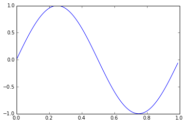

```python
plot(x, sin_n(1))
```

What happens if we display successive $f_n$ on this interval?

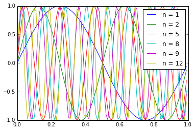

```python
for i in [1, 2, 5, 8, 9, 12]:
    plot(x, sin_n(i), label='n = %i' % i)
legend()
```

But what happens if we sum them?

```python
sum_i_j = lambda i,j: sum([sin_n(k) for k in range(i, j+1)], axis=0)
```

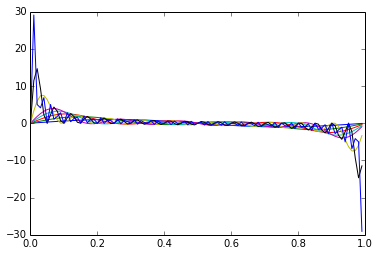

```python
for i in [1, 2, 3, 4, 5, 10, 20, 40]:
    plot(x, sum_i_j(1, i))
```

What does it look like? It looks like all the high frequencies are cancelling each other out to leave just a sort of impulse function.

It turns out that the property I was looking form is linked to the Fourier series of a square waveform. Reference can be found [here](http://www.thefouriertransform.com/series/coefficients.php).

If a square waveform of period T is defined by $$ \left\{ \begin{array}{l l} f(t)= 1 \text{ if } t<T/2 \\ f(t) = 0 \text{ if } t>= T/2 \end{array} \right. $$

```
(-1.1, 2.1)
```

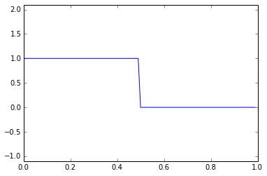

```python
plot(x, x<1/2.)
ylim(-1.1, 2.1)
```

This function, taken as periodic, can be approximated by a Fourier series with formula: $$ F(t) = 1/2 + \sum_{p=0}^{\infty}\frac{2}{\pi (2p+1)} \sin(2 \pi (2 p + 1) t) $$

```python
F_n = lambda n: (1/2. + sum([2./pi/(2*i+1) * sin(2 * pi * (2*i+1) * x) for i in range(n+1)], axis=0))
```

```
(-1.1, 2.1)
```

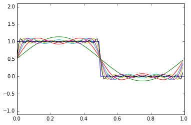

```python
plot(x, x<1/2.)
for i in [0, 1, 2, 3, 5, 10]:
    plot(x, F_n(i))
ylim(-1.1, 2.1)
```

With a high number of harmonics, we get the following approximation:

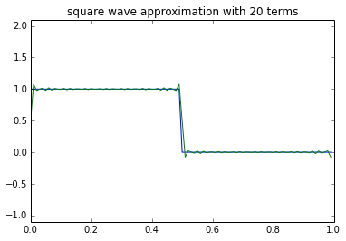

```python
n = 20
plot(x, x<1/2.)
plot(x, F_n(n))
ylim(-1.1, 2.1)
title('square wave approximation with %i terms' % n)
```

A further question one might ask is: what is the link between the Fourier series analysis shown here and the discrete Fourier transform of a rectangular wave pulse?

```python
rect_fft = fft.fft(x<1/2.)
```

```
(0, 50.0)
```

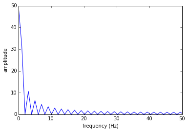

```python
sample_freq = x.size / 1.
plot(linspace(0, 1, rect_fft.size) * sample_freq, abs(rect_fft))
xlabel('frequency (Hz)')
ylabel('amplitude')
xlim(0, sample_freq / 2)
```

As one can see in the plot above, sampling at the natural frequency of the rectangle pulse, every other harmonic component is equal to zero: this is the link with the formula above. In other words, the freqency of the rectangular pulse is 1 Hz, leading to zero components for every even frequency. We can increase the frequency resolution by zero padding our signal:

```python
zero_padded_fft = fft.fft(hstack((x<1/2., zeros(x.shape[0] * 5))))
```

```
(0, 50.0)
```

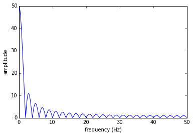

```python
plot(linspace(0, 1, zero_padded_fft.size) * sample_freq, abs(zero_padded_fft))
xlabel('frequency (Hz)')
ylabel('amplitude')
xlim(0, sample_freq / 2)
```

This article has been tagged with the following terms:

[Mathematics](http://flothesof.github.io/tag/mathematics.html)

[figure not shown]